# Juan Movie & TV Analysis - 2019

# Motivation

My friend Juan loves visual media and catalogs his rating of everything he watches over the course of the year. He’s been doing this since 2016 and has recorded **658** movies, TV shows, shorts, and standup specials.

Since IMDB publishes their data [online](https://datasets.imdbws.com/), I wanted to compare how his personal list of ratings compares against the general public for a few key metrics:

- Popularity (number of votes)
- Genre
- Year released
- Runtime
- Year viewed by Juan

To accomplish this, I needed to tackle the following issues:

- Efficiently matching entries by title given the size of the IMDB data ( > 1 GB .tsv files)
- Working with a lot of edge cases, typos, and inconsistently formatted titles from Juan’s list
- Coherently presenting the interesting findings

This is an extension of an effort that I attempted last year, and an opportunity to utilize what I have learned since then.

# The Findings

Lets get straight into the main findings, more details can be found below.

## Fig 1 - Media type

First I wanted to see how Juan’s ratings differed from the general public based on the type of media. These categorizations come from IMDB, with a lot of smaller groups including “short”, and differentiations between a tvMovie and movie. To simplify, I grouped these all into “other”.

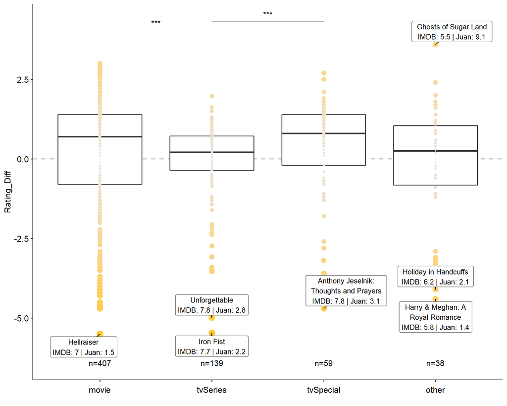

## Fig 2 - Decade

Next, I was interested about how the release date of these movies and tv shows impacted Juan’s rating discrepancy. From these comparisons, Juan thinks that movies from the 80s and 2000s are lacking in comparison to more recent titles. A big factor in this difference may be the boomers that rate all their old favorites on IMDB.

[figure not shown]

## Fig 3 - Genre

Although Juan consistently rates titles higher than the general public when filtering by genre, there are notable differences in his rating variance. For example, it is clear that he consistently likes comedy and documentary titles, while horror titles have a much greater variance.

[figure not shown]

## Fig 4 - Popularity

I created a “Popularity” metric based on how many votes each title got on IMDB. The number of votes were split into 5 quantiles, with the lowest group assigned as “indie”, the largest as “blockbuster”, and the middle 3 as “regular”.

No significant relationship was observed between the three categories, although indie seemed to exhibit less overall variance.

[figure not shown]

## Fig 5 - Votes

To visualize the number of votes in another way, I made a scatter plot comparing log transformed IMDB votes with the difference between Juan’s and IMDB’s ratings. Here, the LOESS smoothed regression line indicates that the relationship is not entirely heteroscedastic - Juan rates less popular movies worse than popular movies. An explanation for this relationship could be that only underground fans of the least popular titles submitted a rating, skewing the IMDB score upward.

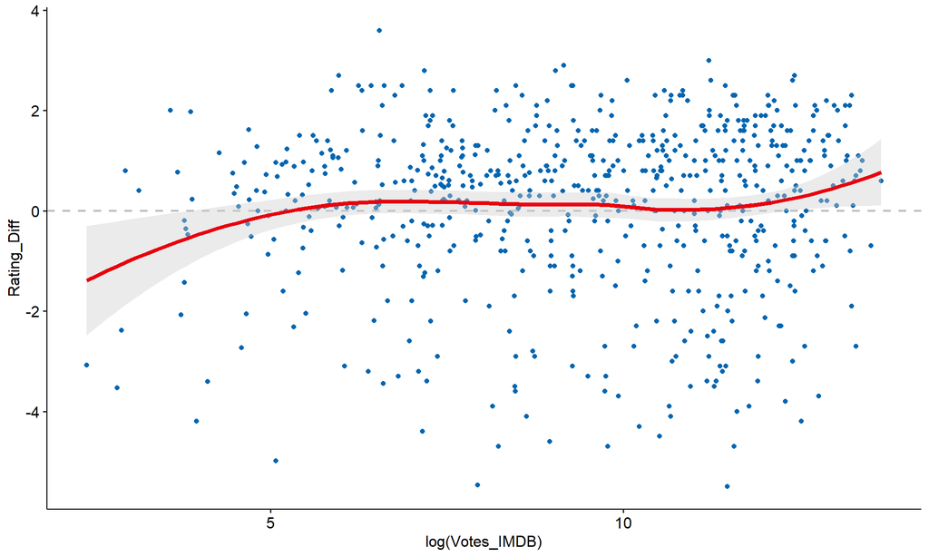

## Fig 6 - Time

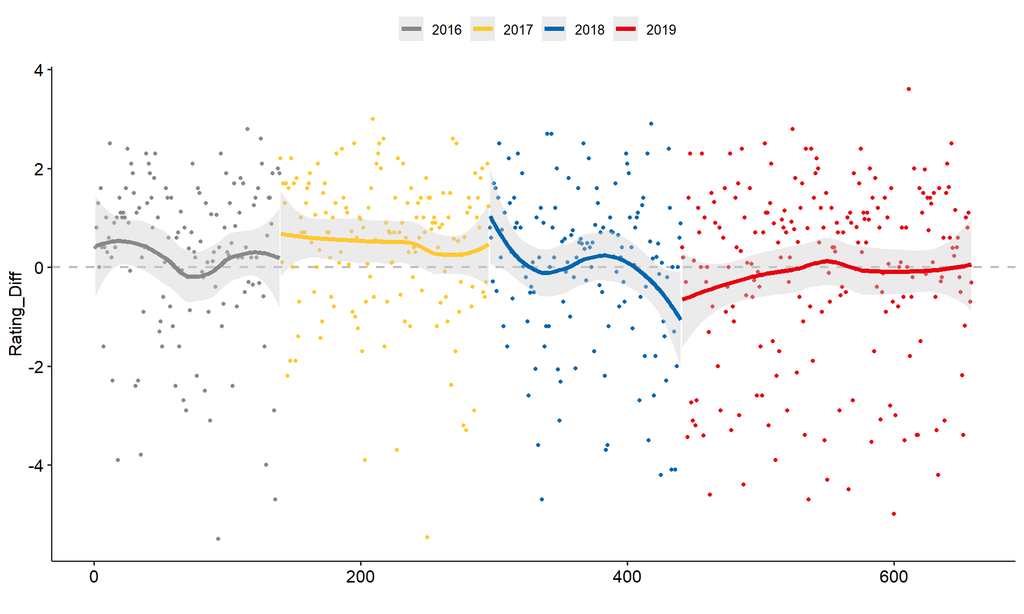

# Behind the Scenes

I used some of my favorite data cleaning libraries to work on this project, including:

```r
library(dplyr)
library(tidyr)
library(data.table)
library(stringr)
```

## Juan’s List

The first step was to read in Juan’s data and see what I was working with

```r
juan_dt = fread('data/juan/movies.csv')
head(juan_dt)
```

```
##                                                 Movie Year
## 1:                                Black Mass (7.3/10) 2016
## 2:                How To Train Your Dragon 2 (8.6/10) 2016
## 3:                             Goodnight Mommy (8/10) 2016
## 4: SpongeBob Square Pants: Sponge Out of Water (6/10) 2016
## 5:                             The Big Short (9.4/10) 2016
## 6:                                The Voices (6.8/10) 2016
```

So he recorded the movie title, a rating out of 10 closed by parentheses, and the year in a second column. In order to match the titles to IMDB’s data, the ratings had to be stripped and placed into their own column.

I used the str_extract function from stringr and some regex magic to match on the number prior to the ‘/’ and place it in its own column called ‘rating’

Breaking down the regex: - (?<=[(]): matches on the left parentheses - (.*?): matches everything after the left parentheses and before the next group - (?=[/]): matches on the forward slash

```r
colnames(juan_dt) = c('Title', 'Viewed')
juan_dt$Rating = str_extract(juan_dt$Title, "(?<=[(])(.*?)(?=[/])")
head(juan_dt)
```

```
##                                                 Title Viewed Rating
## 1:                                Black Mass (7.3/10)   2016    7.3
## 2:                How To Train Your Dragon 2 (8.6/10)   2016    8.6
## 3:                             Goodnight Mommy (8/10)   2016      8
## 4: SpongeBob Square Pants: Sponge Out of Water (6/10)   2016      6
## 5:                             The Big Short (9.4/10)   2016    9.4
## 6:                                The Voices (6.8/10)   2016    6.8
```

```r
juan_dt[nchar(juan_dt$Rating) > 3, ]
```

```
##                       Title Viewed     Rating
## 1: Halloween (2018): 8.9/10   2018 2018): 8.9
## 2:       Heroin(e) (9.2/10)   2019    e) (9.2
```

```r
juan_dt[nchar(juan_dt$Rating) > 3, ][, 'Rating'] = c(8.9, 9.2)
```

Now that all of the numbers were transferred correctly, I updated columns to their correct types

```r
# Convert to numeric
juan_dt$Rating = as.numeric(juan_dt$Rating)

# Viewed
# Convert to factor
juan_dt$Viewed = as.factor(juan_dt$Viewed)
```

Time to clean up those titles with some more regex:

```r
juan_dt$Title_clean = gsub("(?=[(])(.*?)(?<=[)])", '', juan_dt$Title, perl = TRUE)
```

As expected: there were still a lot of edge cases including typos, issues with character conversion. and inconsistently formatted movie years:

```r
# Missing last parentheses
juan_dt$Title_clean = gsub('(?=[(]).*', '', juan_dt$Title_clean, perl = TRUE)
```

```r
# Manually cleaning additional issues & typos
juan_dt$Title_clean[415] = 'Halloween [2018]'
juan_dt$Title_clean = gsub('Hassan Minhaj', 'Hasan Minhaj', juan_dt$Title_clean)
```

```r
# Fix character conversion issues
juan_dt$Title_clean = gsub('â€™', "'", juan_dt$Title_clean)
juan_dt$Title_clean = gsub('Ã', 'i', juan_dt$Title_clean)
juan_dt$Title_clean = gsub('i¼', 'ü', juan_dt$Title_clean)
juan_dt$Title_clean = gsub('i¡', 'a', juan_dt$Title_clean)
juan_dt$Title_clean = gsub('i©', 'e', juan_dt$Title_clean)
```

After fixing the edge cases, I lowered all titles (to be matched with lowered titles from the IMDB dataset, and trimmed their whitespace)

```r
# trim whitespace
juan_dt$Title_clean = trimws(juan_dt$Title_clean)

# lower all titles to aid matching
juan_dt$Title_clean = tolower(juan_dt$Title_clean)
```

Now that the titles have been reformatted, the remake indicators (designated by left and right brackets containing a year) need to be pulled and removed. I used the same strategy as with the ratings:

```r
# Add remake col
juan_dt$Year = str_extract(juan_dt$Title_clean, '\\d{4}')

# exclude edge cases
year_cases = c('blade runner: 2049', 'the shop: 2018 episodes', '2017')
juan_dt[juan_dt$Title_clean %in% year_cases][, 'Year'] = NA

# remove years from titles
juan_dt$Title_clean = gsub('(\\[)(\\d{4})(\\])', '', juan_dt$Title_clean)
```

One last thing: removing seasons indicators and putting them in their own column

```r
# Add season col
juan_dt$Season = str_extract(juan_dt$Title_clean, '(?<=season |series |volume )(\\d{2}|\\d{1})')

# Fix edge case
juan_dt[juan_dt$Title_clean == 'axe cop: seasons 1-2'][, 'Season'] = '1-2'
juan_dt[juan_dt$Title_clean == 'axe cop: seasons 1-2'][, 'Title_clean'] = 'axe cop'

# remove seasons from titles
remove_seasons = '(?i)(: |! | - |\\? | )(season |series |volume |part )(\\d{2}|\\d{1})'
juan_dt$Title_clean = gsub(remove_seasons, '', juan_dt$Title_clean)

# trim whitespace again
juan_dt$Title_clean = trimws(juan_dt$Title_clean)
```

```r
# drop unformatted title
juan_dt$Title = NULL

colnames(juan_dt)[3] = 'Title'

# add id to ensure data is not lost
juan_dt$ID_Juan = seq(1: nrow(juan_dt))
```

## IMDB’s … DB

And that’s it for Juan’s data! Now onto the IMDB monolith:

```r
imdb_full = fread('data/imdb/title_basics.tsv', sep = '\t', na.strings = '\\N')
imdb_ratings = fread('data/imdb/title_ratings.tsv', sep = '\t')
imdb_season = fread('data/imdb/title_episode.tsv', sep = '\t')
```

That seemed to take a while, I wonder why?

```r
object.size(imdb_full)
```

```
## 1290330104 bytes
```

```r
nrow(imdb_full)
```

```
## [1] 6434874
```

```r
nrow(imdb_ratings)
```

```
## [1] 1008306
```

```r
nrow(imdb_season)
```

```
## [1] 4539038
```

Oh. Let’s check what is in each dataset:

```r
head(imdb_full)
```

```
##       tconst titleType           primaryTitle          originalTitle isAdult
## 1: tt0000001     short             Carmencita             Carmencita       0
## 2: tt0000002     short Le clown et ses chiens Le clown et ses chiens       0
## 3: tt0000003     short         Pauvre Pierrot         Pauvre Pierrot       0
## 4: tt0000004     short            Un bon bock            Un bon bock       0
## 5: tt0000005     short       Blacksmith Scene       Blacksmith Scene       0
## 6: tt0000006     short      Chinese Opium Den      Chinese Opium Den       0
##    startYear endYear runtimeMinutes                   genres
## 1:      1894      NA              1        Documentary,Short
## 2:      1892      NA              5          Animation,Short
## 3:      1892      NA              4 Animation,Comedy,Romance
## 4:      1892      NA             NA          Animation,Short
## 5:      1893      NA              1             Comedy,Short
## 6:      1894      NA              1                    Short
```

```r
head(imdb_ratings)
```

```
##       tconst averageRating numVotes
## 1: tt0000001           5.6     1564
## 2: tt0000002           6.1      188
## 3: tt0000003           6.5     1229
## 4: tt0000004           6.1      114
## 5: tt0000005           6.1     1960
## 6: tt0000006           5.2      105
```

```r
head(imdb_season)
```

```
##       tconst parentTconst seasonNumber episodeNumber
## 1: tt0041951    tt0041038            1             9
## 2: tt0042816    tt0989125            1            17
## 3: tt0042889    tt0989125          \\N           \\N
## 4: tt0043426    tt0040051            3            42
## 5: tt0043631    tt0989125            2            16
## 6: tt0043693    tt0989125            2             8
```

Using these full data sets would make cleaning and especially matching much more cumbersome. First step is to drop the unneeded entries and fix the column names:

```r
imdb_full$endYear = NULL
colnames(imdb_full) = c('tconst' ,'Type_IMDB', 'Title', 'Title_IMDB', 'Adult_YN', 'Year_IMDB', 'Runtime', 'Genres')

# cut down imdb_full length
kept_types = c('movie', 'tvMiniSeries', 'tvMovie', 'tvSeries', 'tvSpecial', 'short', 'video', 'tvShort')
imdb_short = imdb_full[Type_IMDB %in% kept_types]
imdb_short$Year_IMDB = as.numeric(imdb_short$Year_IMDB)
imdb_short = imdb_short[Year_IMDB >= 1920]
```

Now lets check the number of rows:

```r
(nrow(imdb_short) / nrow(imdb_full)) * 100
```

```
## [1] 26.05681
```

Not a bad improvement. Now to modify the shortened data and merge the title information with the ratings and number of votes

```r
# merge ratings
imdb_short = imdb_ratings[imdb_short, on = 'tconst']
colnames(imdb_short)[2:3] = c('Rating_IMDB', 'Votes_IMDB')

imdb_dt = imdb_short[!is.na(imdb_short$Votes_IMDB) & imdb_short$Votes_IMDB > 300 & !is.na(imdb_short$Genres), ]

# lower titles
imdb_dt$Title = tolower(imdb_dt$Title)
```

The titles in the reduced dataset are now lowered and can be matched with juan’s entries

```r
merged_full = juan_dt
merged_full = imdb_dt[merged_full, on = 'Title']


# copy for cleaning
merged_dt = merged_full
```

## Cleaning

Round 1: Strict, automated cuts

```r
Drop_Check = function(old_dropped, new_df){
  new_ids = unique(unlist(new_df[, 'ID_Juan']))
  all_ids = unlist(juan_dt[, 'ID_Juan'])
  new_dropped = juan_dt[!(all_ids %in% new_ids)][, 'ID_Juan']
  out = append(old_dropped, new_dropped)
  return(unique(unlist(out)))
}

Get_Dupe = function(x){return(duplicated(x) | duplicated(x, fromLast = TRUE))}
```

```r
# # drop titles that did not match an imdb entry
merged_dt = merged_dt[!is.na(tconst)]

# null b/c first time function is called so nothing to append to
dropped_ids = Drop_Check(NULL, merged_dt)

# if a title contains a season, then drop anything besides tvSeries
merged_dt = merged_dt[!(!is.na(Season) & Type_IMDB != 'tvSeries')]
dropped_ids = Drop_Check(dropped_ids, merged_dt)

# match entry to rerun year
merged_dt = merged_dt[(!is.na(Year) & Year == Year_IMDB) | is.na(Year)]

# sort by votes and keep the top entry for duplicated entries
merged_dt = merged_dt[merged_dt[, .I[which.max(Votes_IMDB)], by=ID_Juan]$V1]
dropped_ids = Drop_Check(dropped_ids, merged_dt)

# Change titles of dropped ids, then remerge
merged_redo1 = juan_dt[juan_dt$ID_Juan %in% dropped_ids]
merged_check1 = merged_full[merged_full$ID_Juan %in% dropped_ids]
```

Lets see how many titles were dropped:

```r
dropped_ids
```

```
##   [1]   4   8  10  12  24  26  37  51  59  63  65  85  86  87  92  95 106 107
##  [19] 111 117 119 135 143 151 155 159 163 164 165 171 177 181 183 188 192 195
##  [37] 197 199 200 207 214 235 246 266 267 275 277 281 289 292 293 302 313 317
##  [55] 319 320 323 333 334 335 337 339 340 342 348 352 354 356 361 372 373 382
##  [73] 385 387 391 395 396 398 402 412 416 426 432 434 443 444 446 467 471 477
##  [91] 486 487 488 491 496 506 510 514 516 518 522 525 529 530 531 534 541 544
## [109] 546 547 552 561 563 565 579 580 581 582 583 585 588 589 590 591 602 606
## [127] 607 609 610 616 621 623 626 627 630 633 635 643 644 647 657  72 167
```

A lot. And most of them are due to irregular discrepancies between how IMDB classified a title and how Juan did. This part will take some manual entry by searching Juan’s entry on IMDB and typing in the closest match.

In the future, I could try a fuzzy matching approach in Python.

```r
title_changes = c(
  c("art and copy", "art & copy"),
  c("american crime story: the people vs. o.j simpson", "american crime story"),
  c("angry birds: the movie", "the angry birds movie"),
  c("ant-man and wasp", "ant-man and the wasp"),
  c("autumn's sonata", "autumn sonata"),
  c("best of enemies", "the best of enemies"),
  c("bobs burgers", "bob's burgers"),
  c("blade runner: 2049", "blade runner 2049"),
  c("blade runner: the final cut", "blade runner"),
  c("central park five", "the central park five"),
  c("chris rock: tambourine", "chris rock: tamborine"),
  c("christina p. mother inferior", "christina p: mother inferior"),
  c("clarence clemons: who do you think i am?", "clarence clemons: who do i think i am?"),
  c("dave chappelle: deep in the heart of texas", "Deep in the Heart of Texas: Dave Chappelle Live at Austin City Limits"),
  c("dave chappelle: sticks and stones", "dave chappelle: sticks & stones"),
  c("david cross: making america great again!", "david cross: making america great again"),
  c("demitri martin: the overthinker", "demetri martin: the overthinker"),
  c("detective pikachu", "PokÃ©mon Detective Pikachu"),
  c("documentary now", "documentary now!"),
  c("el infierno", "el narco"),
  c("everybody wants some", "everybody wants some!!"),
  c("frankenstein's monster's monster, frankenstein", "Frankenstein's Monster's Monster, Frankenstein"),
  c("friday the 13th, part vi: jason lives", "Friday the 13th Part VI: Jason Lives"),
  c("garfunkel & oates: trying to be special", "garfunkel and oates: trying to be special"),
  c("evil genius: the true story about america's most diabolical bank heist", "Evil Genius: The True Story of America's Most Diabolical Bank Heist"),
  c("furious seven", "furious 7"),
  c("ghostbusters: 2016", "ghostbusters"),
  c("guardians of the galaxy: vol 2", "guardians of the galaxy vol. 2"),
  c("handsome: a netflix murder mystery movie", "handsome: a netflix mystery movie"),
  c("hannah gadsby: nannette", "hannah gadsby: nanette"),
  c("harry and meghan: a royal romance", "harry & meghan: a royal romance"),
  c("hearts of darkness", "Hearts of Darkness: A Filmmaker's Apocalypse"),
  c("hello mary lou: prom night 2", "prom night II"),
  c("heroin", "heroin(e)"),
  c("hobbs and shaw", "Fast & Furious Presents: Hobbs & Shaw"),
  c("hottie and the nottie", "the hottie & the nottie"),
  c("i think you should leave - with tim robinson", "i think you should leave with tim robinson"),
  c("insidious 3", "insidious: chapter 3"),
  c("it: chapter 2", "it chapter two"),
  c("jaws iii", "Jaws 3-D"),
  c("jerry seinfeld: i'm telling you for the last time", "Jerry Seinfeld: 'I'm Telling You for the Last Time'"),
  c("jew süss", "Jud SÃ¼ÃŸ"),
  c("jimmy carr: the best pf ultimate gold greatest hits", "jimmy carr: the best of ultimate gold greatest hits"),
  c("joe mande: an award winning special", "Joe Mande's Award-Winning Comedy Special"),
  c("john wick 3: parabellum", "John Wick: Chapter 3 - Parabellum"),
  c("king of kong: a fistful of quarters", "The King of Kong: A Fistful of Quarters"),
  c("lego movie 2", "the lego movie 2: the second part"),
  c("lil rel howrey: live in crenshaw", "lil rel howery: live in crenshaw"),
  c("louis c.k: live at the comedy store", "louis c.k.: live at the comedy store"),
  c("love, death, and robots", "love, death & robots"),
  c("lucas bros: on drugs", "lucas brothers: on drugs"),
  c("lupin the 3rd: the castle it cagliostro", "lupin the 3rd: castle of cagliostro"),
  c("m.", "m"),
  c("michael bolton's big sexy valentine's day special", "michael bolton's big, sexy valentine's day special"),
  c("mission impossible: fallout", "mission: impossible - fallout"),
  c("muse: kobe bryant", "kobe bryant's muse"),
  c("nailed it", "nailed it!"),
  c("neal brennan: three mics", "Neal Brennan: 3 Mics"),
  c("norm macdonald: hitler's dog, gossip and trickery", "norm macdonald: hitler's dog, gossip & trickery"),
  c("nosferatu: a symphony of horror", "nosferatu"),
  c("nosferatu: phantom of the night", "Nosferatu the Vampyre"),
  c("oceans 8", "ocean's eight"),
  c("oh, hello: on broadway", "oh, hello on broadway"),
  c("once upon a time in hollywood", "Once Upon a Time... in Hollywood"),
  c("pixles", "pixels"),
  c("planes, trains and automobiles", "Planes, Trains & Automobiles"),
  c("patrick melrose: miniseries", "patrick melrose"),
  c("patriot act, with hasan minhaj", "patriot act with hasan minhaj"),
  c("pop star: never stop never stopping", "popstar: never stop never stopping"),
  c("queen and slim", "queen & slim"),
  c("queer eye: we're in japan", "queer eye: we're in japan!"),
  c("red riding: 1974", "Red Riding: The Year of Our Lord 1974"),
  c("red riding: 1980", "Red Riding: The Year of Our Lord 1980"),
  c("red riding: 1983", "Red Riding: The Year of Our Lord 1983"),
  c("saturday night live: david s. pumpkin halloween special", "The David S. Pumpkins Halloween Special"),
  c("seth myers: lobby baby", "seth meyers: lobby baby"),
  c("sky captain: and the world pf tomorrow", "sky captain and the world of tomorrow"),
  c("sky ladder: the art of cai� guo-qiang", "Sky Ladder: The Art of Cai Guo-Qiang"),
  c("spider-man: into the spiderverse", "spider-man: into the spider-verse"),
  c("show me a hero: complete mini series", "show me a hero"),
  c("spongebob square pants: sponge out of water", "The SpongeBob Movie: Sponge Out of Water"),
  c("star crash", "starcrash"),
  c("star trek: into darkness", "star trek into darkness"),
  c("star wars: rise of skywalker", "Star Wars: Episode IX - The Rise of Skywalker"),
  c("star wars: the last jedi", "Star Wars: Episode VIII - The Last Jedi"),
  c("spawn", "todd mcfarlane's spawn"),
  c("the avengers: infinity war", "avengers: infinity war"),
  c("the barkley marathons", "The Barkley Marathons: The Race That Eats Its Young"),
  c("the breaker uppers", "the breaker upperers"),
  c("the end of the fucking world", "The End of the F***ing World"),
  c("the incredibles 2", "incredibles 2"),
  c("the jerrod carmichael show", "the carmichael show"),
  c("the man from u.n.c.l.e", "the man from u.n.c.l.e."),
  c("the lonely island presents: the unauthorized bash brothers experience", "The Unauthorized Bash Brothers Experience"),
  c("the lucas bros moving co", "lucas bros moving co   "),
  c("the old man and the gun", "the old man & the gun"),
  c("the shop: 2018 episodes", "the shop"),
  c("three hazelnuts for cinderella", "Three Wishes for Cinderella"),
  c("the world of tomorrow", "World of Tomorrow"),
  c("tim and eric: awesome show great job", "Tim and Eric Awesome Show, Great Job!"),
  c("tj miller: ridiculous", "T.J. Miller: Meticulously Ridiculous"),
  c("too funny to fail: the life and death of the dana carvey show", "Too Funny to Fail: The Life & Death of The Dana Carvey Show"),
  c("ugly delicious presents - breakfast, lunch and dinner", "Breakfast, Lunch & Dinner"),
  c("war for planet of the apes", "War for the Planet of the Apes"),
  c("wes craven's: new nightmare", "Wes Craven's New Nightmare"),
  c("wet hot american summer: 10 years later", "Wet Hot American Summer: Ten Years Later"),
  c("you laugh, but it's true", "You Laugh But It's True"),
  c("james acaster: repertoire - recognise", "recognise"),
  c("james acaster: repertoire - recap", "recap"),
  c("james acaster: repertoire - represent", "represent"),
  c("james acaster: repertoire - reset", "reset"),
  c("jerrod carmichael: home videos", "home videos"),
  c("jerrod carmichael: sermon on the hill", "sermon on the mount"),
  c("rhys darby: night!", "rhys darby: it's rhys darby night!"),
  c("they call it myanmar", "they call it myanmar: lifting the curtain"),
  c("daniel sloss: dark", "dark"),
  c("daniel sloss: jigsaw", "jigsaw"),
  c("sherlock: the abominable bride", "The Abominable Bride"))

# classified as tv episodes
full_dt_titles = c('white right: meeting the enemy', 'the abominable bride',
                   'recognise', 'recap', 'represent', 'reset', 'home videos', 'sermon on the mount',
                   'ramy youssef: feelings', "rhys darby: i'm a fighter jet", "rhys darby: it's rhys darby night!",
                   "the price of gold", "they call it myanmar: lifting the curtain", 'daniel sloss: x', 'dark',
                   'jigsaw', 'clarence clemons: who do i think i am?', 't.j. miller: meticulously ridiculous',
                   'lil rel howery: live in crenshaw')

unsure_titles = c('children of the sun', '2017', 'a murder among us', 'big mouth: my furry valentine',
                  'dave chappelle: live in la', 'derek [special]', 'football fight club', 'little miss sumo')

# various episodes across multiple seasons / not on imdb
dropped_titles = c('conan abroad', 'party monster: scratching the surface', 'race, power and american sports',
                   "rhys darby: this way to spaceship!")
```

```r
# replace titles
title_changes = trimws(tolower(title_changes))

original_titles = title_changes[seq(1, length(title_changes), 2)]
new_titles = title_changes[seq(2, length(title_changes), 2)]
merged_redo1$Title = mgsub::mgsub(merged_redo1$Title, original_titles, new_titles, recycle = FALSE, fixed=TRUE)

# keep only titles that can be changed with the shortened imdb_dt
merged_redo2 = merged_redo1[!(merged_redo1$Title %in% dropped_titles |
                              merged_redo1$Title %in% unsure_titles |
                              merged_redo1$Title %in% full_dt_titles)]

# additional fixes
merged_redo2[merged_redo2$ID_Juan == 214][, 'Title'] = 'sky ladder: the art of cai guo-qiang'
merged_redo2[merged_redo2$ID_Juan %in% c(544, 546, 547)][, 'Year'] = NA
merged_redo2[merged_redo2$ID_Juan == 167][, 'Year'] = 1995

merged_redo1[!(merged_redo1$ID_Juan %in% merged_redo2$ID_Juan)]
```

```
##     Viewed Rating                                     Title Year Season ID_Juan
##  1:   2016    7.0                      the abominable bride <NA>   <NA>      59
##  2:   2016    8.0                       children of the sun <NA>   <NA>     117
##  3:   2017    8.8                         a murder among us <NA>   <NA>     164
##  4:   2017    6.8                         the price of gold <NA>   <NA>     165
##  5:   2017    7.8                dave chappelle: live in la <NA>   <NA>     183
##  6:   2017    8.1           race, power and american sports <NA>   <NA>     188
##  7:   2017    4.8                       football fight club <NA>   <NA>     192
##  8:   2017    8.4 they call it myanmar: lifting the curtain <NA>   <NA>     281
##  9:   2018    8.3        rhys darby: this way to spaceship! <NA>   <NA>     319
## 10:   2018    7.1        rhys darby: it's rhys darby night! <NA>   <NA>     320
## 11:   2018    7.5             rhys darby: i'm a fighter jet <NA>   <NA>     323
## 12:   2018    8.2                                 recognise <NA>   <NA>     342
## 13:   2018    8.0                                 represent <NA>   <NA>     354
## 14:   2018    8.5                                     reset <NA>   <NA>     373
```

[output cut: 18 more lines]

```r
merged_redo2 = imdb_dt[merged_redo2, on = 'Title']
```

Round 2:

```r
# identify dupes
merged_redo2[Get_Dupe(merged_redo2$ID_Juan)]
```

```
##        tconst Rating_IMDB Votes_IMDB Type_IMDB                   Title
##  1: tt0054678         6.8        518     movie     the best of enemies
##  2: tt4807408         7.0       5136     movie     the best of enemies
##  3: tt0057765         7.7       4407  tvSeries the man from u.n.c.l.e.
##  4: tt1638355         7.3     248610     movie the man from u.n.c.l.e.
##  5: tt1635656         7.5       1771     short                  pixels
##  6: tt2120120         5.6     123822     movie                  pixels
##  7: tt0118475         8.1       6986  tvSeries  todd mcfarlane's spawn
##  8: tt4641774         8.5        887     video  todd mcfarlane's spawn
##  9: tt0087332         7.8     335211     movie            ghostbusters
## 10: tt1289401         5.2     193770     movie            ghostbusters
## 11: tt0022100         8.3     132980     movie                       m
## 12: tt0043766         6.8       1523     movie                       m
## 13: tt0889615         6.2        424     movie                       m
## 14: tt5137242         6.5        351     movie                       m
```

[output cut: 36 more lines]

```r
# drop if release year is after watched year
merged_redo2 = merged_redo2[as.numeric(as.character(merged_redo2$Viewed)) >= Year_IMDB]

# match sequel year
merged_redo2 = merged_redo2[!(!is.na(Year) & Year_IMDB != Year)]

# keep most voted
merged_redo2 = merged_redo2[merged_redo2[, .I[which.max(Votes_IMDB)], by=ID_Juan]$V1]

# add fixed titles to new manual df
merged_manual = rbind(merged_dt, merged_redo2)
```

Round 3:

```r
# merge with full imdb
merged_special = merged_redo1[Title %in% full_dt_titles]

# imdb_full$primaryTitle = tolower(imdb_full$primaryTitle)
imdb_full$Title = tolower(imdb_full$Title)

merged_special = imdb_full[merged_special, on = 'Title']

merged_special = merged_special[!(ID_Juan == 165 & Year_IMDB != 2014)]

tv_episode_ids = c(59, 165, 354, 373, 396, 412, 444, 534)

merged_special = merged_special[!(ID_Juan %in% tv_episode_ids & Type_IMDB != 'tvEpisode')]

tv_movie_ids  = c(582)
merged_special = merged_special[!(ID_Juan %in% tv_movie_ids & Type_IMDB != 'tvMovie')]

merged_special = merged_special[!(ID_Juan == 563 & Type_IMDB != 'tvSeries')]

merged_special = merged_special[!(ID_Juan %in% c(373, 396, 412, 444) & (Year_IMDB != 2018 | Genres != 'Comedy'))]
merged_special = merged_special[!(ID_Juan == 373 & tconst != 'tt7894296')]

# merge w/ ratings
merged_special = imdb_ratings[merged_special, on = 'tconst']
colnames(merged_special)[2:3] = c('Rating_IMDB', 'Votes_IMDB')

# add to merged_manual
merged_manual = rbind(merged_manual, merged_special)

# Cleaning round 4 ----
# fix manual types (video)
merged_manual[Type_IMDB == 'video'][, 'Type_IMDB'] = 'tvSpecial'

# check what is still missing
dropped_ids = Drop_Check(NULL, merged_manual)

merged_full[merged_full$ID_Juan %in% dropped_ids]  # fine
```

```
##     tconst Rating_IMDB Votes_IMDB Type_IMDB
##  1:   <NA>          NA         NA      <NA>
##  2:   <NA>          NA         NA      <NA>
##  3:   <NA>          NA         NA      <NA>
##  4:   <NA>          NA         NA      <NA>
##  5:   <NA>          NA         NA      <NA>
##  6:   <NA>          NA         NA      <NA>
##  7:   <NA>          NA         NA      <NA>
##  8:   <NA>          NA         NA      <NA>
##  9:   <NA>          NA         NA      <NA>
## 10:   <NA>          NA         NA      <NA>
## 11:   <NA>          NA         NA      <NA>
## 12:   <NA>          NA         NA      <NA>
##                                     Title Title_IMDB Adult_YN Year_IMDB Runtime
##  1:                   children of the sun       <NA>       NA        NA      NA
```

[output cut: 24 more lines]

## Post-Processing

```r
# Assume missing season is the first one
merged_manual[Type_IMDB == 'tvSeries' & is.na(Season)][, 'Season'] = 1

tv_ids = unlist(merged_manual[Type_IMDB == 'tvSeries'][, 'tconst'])

tv_dt = imdb_season[parentTconst %in% tv_ids]
tv_dt = imdb_ratings[tv_dt, on = 'tconst']

# Change IMDB Votes and Ratings for seasons of TV
for (id in tv_ids) {

  row_select = merged_manual[tconst == id, ]

  for (season in unlist(row_select[, 'Season'])){
    tv_subset = tv_dt[parentTconst == id & seasonNumber == season]

    votes = mean(unlist(tv_subset[, 'numVotes']), na.rm = TRUE)
    ratings = mean(unlist(tv_subset[, 'averageRating']), na.rm = TRUE)
    episodes = length(unlist(tv_subset[, 'episodeNumber']))

    dt_row = which(merged_manual$tconst == id & merged_manual$Season == season)

    merged_manual[dt_row, 'Rating_IMDB'] = ratings
    merged_manual[dt_row, 'Votes_IMDB'] = votes
    merged_manual[dt_row, 'Episodes'] = episodes
  }
}


# add top genres
setDT(merged_manual)[, 'Top_Genre':= tstrsplit(Genres, ',')[1]]

# add rating_delta
setDT(merged_manual)[, 'Rating_Diff':= (Rating - Rating_IMDB)]

# ensure types are ready for analysis
summary(merged_manual)
```

```
##     tconst           Rating_IMDB      Votes_IMDB      Type_IMDB
##  Length:646         Min.   :1.900   Min.   :    11   Length:646
##  Class :character   1st Qu.:6.600   1st Qu.:  1693   Class :character
##  Mode  :character   Median :7.300   Median : 16004   Mode  :character
##                     Mean   :7.184   Mean   : 78639
##                     3rd Qu.:7.900   3rd Qu.: 96355
##                     Max.   :9.060   Max.   :852043
##                     NA's   :3       NA's   :3
##     Title            Title_IMDB           Adult_YN   Year_IMDB
##  Length:646         Length:646         Min.   :0   Min.   :1920
##  Class :character   Class :character   1st Qu.:0   1st Qu.:2013
##  Mode  :character   Mode  :character   Median :0   Median :2016
##                                        Mean   :0   Mean   :2012
##                                        3rd Qu.:0   3rd Qu.:2017
##                                        Max.   :0   Max.   :2019
##
##     Runtime          Genres           Viewed        Rating
##  Min.   : 11.00   Length:646         2016:138   Min.   : 0.300
##  1st Qu.: 60.00   Class :character   2017:153   1st Qu.: 6.300
##  Median : 93.00   Mode  :character   2018:143   Median : 8.000
##  Mean   : 85.43                      2019:212   Mean   : 7.308
##  3rd Qu.:110.00                                 3rd Qu.: 8.800
##  Max.   :358.00                                 Max.   :10.000
##  NA's   :9
##      Year              Season             ID_Juan         Episodes
##  Length:646         Length:646         Min.   :  1.0   Min.   : 0.000
##  Class :character   Class :character   1st Qu.:163.5   1st Qu.: 6.000
##  Mode  :character   Mode  :character   Median :329.5   Median : 8.000
##                                        Mean   :329.0   Mean   : 9.872
##                                        3rd Qu.:494.8   3rd Qu.:12.000
##                                        Max.   :658.0   Max.   :43.000
##                                                        NA's   :505
##   Top_Genre          Rating_Diff
##  Length:646         Min.   :-5.500
##  Class :character   1st Qu.:-0.600
##  Mode  :character   Median : 0.500
##                     Mean   : 0.119
##                     3rd Qu.: 1.221
##                     Max.   : 3.600
##                     NA's   :3
```

```r
merged_manual$Top_Genre = as.factor(merged_manual$Top_Genre)
merged_manual$Year = as.numeric(merged_manual$Year)
merged_manual$Type_IMDB = as.factor(merged_manual$Type_IMDB)

qcut = function(x, n) {
  quantiles = seq(0, 1, length.out = n+1)
  cutpoints = unname(quantile(x, quantiles, na.rm = TRUE))
  cut(x, cutpoints, include.lowest = TRUE)
}

merged_manual$Year_Group = cut(merged_manual$Year_IMDB,
                         breaks = c(1919, 1979, 1999, 2009, 2014, 2019),
                         labels = c('1920 - 1980', '1980 - 2000', '2000 - 2010',
                                    '2010 - 2015', '2015 - 2020'))

setDT(merged_manual)[, Popularity := qcut(Votes_IMDB, 5)]
levels(merged_manual$Popularity) = c('Indie', 'Regular', 'Regular', 'Regular', 'Blockbuster')

merged_manual$Type_IMDB = as.factor(merged_manual$Type_IMDB)

other_types = !(levels(merged_manual$Type_IMDB) %in% c('movie', 'tvSeries', 'tvSpecial'))
levels(merged_manual$Type_IMDB)[other_types] = 'other'

merged_manual$Top_Genre = as.factor(merged_manual$Top_Genre)
other_genres = (levels(merged_manual$Top_Genre) %in% c('Animation', 'Reality-TV', 'Fantasy', 'Music', 'Talk-Show'))
levels(merged_manual$Top_Genre)[other_genres] = 'Other'

merged_manual$Label = with(merged_manual, paste0(str_wrap(Title_IMDB, 20),
                                     '\nIMDB: ', round(Rating_IMDB, 1),
                                     ' | Juan: ', Rating))
```

```r
# export to different file to avoid loading times
write.csv(merged_manual, 'data/juan/cleaned_data.csv', row.names = FALSE)
```